## chapter1.모델링을 위한 전처리

## 문제0

tidyverse, data.table, gridExtra를 부른 후, setwd로 ‘data.csv’ 및 ‘test.csv’가 있는 폴더로 경로를 설정하고, fread로 ‘data.csv’와 ‘test.csv’를 불러오세요

```r
library(tidyverse)
library(data.table)
library(gridExtra)
setwd('C:/Users/bounc/Desktop/3주차패키지')
train_data=fread('data.csv')
test_data=fread('test.csv')
```

# 문제1

‘bmi(bmi 지수)’ 변수를 numeric 자료형으로 바꾸고, NA값을 mean imputation으로 채우세요

```r
mean_imputation = function(x){
    ifelse(is.na(x),mean(x,na.rm=T),x)
}
train_data = train_data %>% mutate(bmi=as.numeric(bmi)) %>% mutate(bmi=mean_imputation(bmi))
str(train_data)
```

```
## Classes 'data.table' and 'data.frame':   4087 obs. of  12 variables:
##  $ id               : int  9046 51676 31112 60182 1665 53882 10434 27419 60491 12109 ...
##  $ gender           : chr  "Male" "Female" "Male" "Female" ...
##  $ age              : num  67 61 80 49 79 74 69 59 78 81 ...
##  $ hypertension     : int  0 0 0 0 1 1 0 0 0 1 ...
##  $ heart_disease    : int  1 0 1 0 0 1 0 0 0 0 ...
##  $ ever_married     : chr  "Yes" "Yes" "Yes" "Yes" ...
##  $ work_type        : chr  "Private" "Self-employed" "Private" "Private" ...
##  $ Residence_type   : chr  "Urban" "Rural" "Rural" "Urban" ...
##  $ avg_glucose_level: num  229 202 106 171 174 ...
##  $ bmi              : num  36.6 28.8 32.5 34.4 24 ...
##  $ smoking_status   : chr  "formerly smoked" "never smoked" "never smoked" "smokes" ...
##  $ stroke           : int  1 1 1 1 1 1 1 1 1 1 ...
##  - attr(*, ".internal.selfref")=<externalptr>
```

bmi가 numeric으로 바뀌었고, NA는 평균인 28.82782로 채워짐

## 문제2

문자형(character) 변수를 명목형 변수(factor)로 바꾸세요.

```r
train_data = train_data %>% mutate_if(is.character,as.factor)
str(train_data)
```

```
## Classes 'data.table' and 'data.frame':   4087 obs. of  12 variables:
##  $ id               : int  9046 51676 31112 60182 1665 53882 10434 27419 60491 12109 ...
##  $ gender           : Factor w/ 3 levels "Female","Male",..: 2 1 2 1 1 2 1 1 1 1 ...
##  $ age              : num  67 61 80 49 79 74 69 59 78 81 ...
##  $ hypertension     : int  0 0 0 0 1 1 0 0 0 1 ...
##  $ heart_disease    : int  1 0 1 0 0 1 0 0 0 0 ...
##  $ ever_married     : Factor w/ 2 levels "No","Yes": 2 2 2 2 2 2 1 2 2 2 ...
##  $ work_type        : Factor w/ 5 levels "children","Govt_job",..: 4 5 4 4 5 4 4 4 4 4 ...
##  $ Residence_type   : Factor w/ 2 levels "Rural","Urban": 2 1 1 2 1 1 2 1 2 1 ...
##  $ avg_glucose_level: num  229 202 106 171 174 ...
##  $ bmi              : num  36.6 28.8 32.5 34.4 24 ...
##  $ smoking_status   : Factor w/ 4 levels "formerly smoked",..: 1 2 2 3 2 2 2 4 4 2 ...
##  $ stroke           : int  1 1 1 1 1 1 1 1 1 1 ...
##  - attr(*, ".internal.selfref")=<externalptr>
```

문자형 변수들이 명목형 변수들로 바뀜

## 문제3

‘id’ 변수를 제거하세요.

```r
train_data = train_data %>% select(-id)
str(train_data)
```

```
## Classes 'data.table' and 'data.frame':   4087 obs. of  11 variables:
##  $ gender           : Factor w/ 3 levels "Female","Male",..: 2 1 2 1 1 2 1 1 1 1 ...
##  $ age              : num  67 61 80 49 79 74 69 59 78 81 ...
##  $ hypertension     : int  0 0 0 0 1 1 0 0 0 1 ...
##  $ heart_disease    : int  1 0 1 0 0 1 0 0 0 0 ...
##  $ ever_married     : Factor w/ 2 levels "No","Yes": 2 2 2 2 2 2 1 2 2 2 ...
##  $ work_type        : Factor w/ 5 levels "children","Govt_job",..: 4 5 4 4 5 4 4 4 4 4 ...
##  $ Residence_type   : Factor w/ 2 levels "Rural","Urban": 2 1 1 2 1 1 2 1 2 1 ...
##  $ avg_glucose_level: num  229 202 106 171 174 ...
##  $ bmi              : num  36.6 28.8 32.5 34.4 24 ...
##  $ smoking_status   : Factor w/ 4 levels "formerly smoked",..: 1 2 2 3 2 2 2 4 4 2 ...
##  $ stroke           : int  1 1 1 1 1 1 1 1 1 1 ...
##  - attr(*, ".internal.selfref")=<externalptr>
```

id 제거됨

## 문제4

타겟(stoke)값 별로 범주형 변수의 분포를 다음과 같이 시각화 하고, 간단히 해석해보세요.(gather, gridExtra 패키지 내 함수 이용).

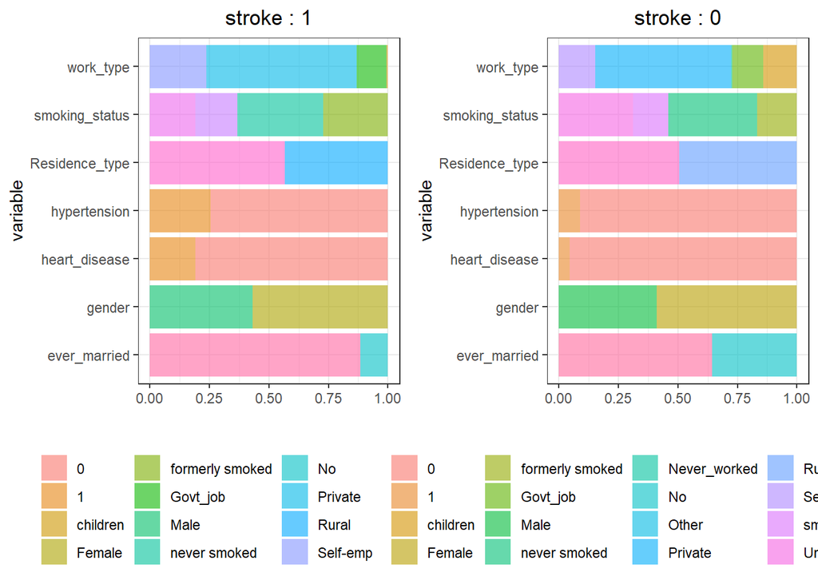

```r
is.integer = function(x){
  class(x)=="integer"
}
train_data = train_data %>% mutate_if(is.integer,as.factor) # 범주형 변수 생성
p1 = train_data %>% select(where((is.factor))) %>% gather(key='variable', value='value',-stroke) %>% filter(stroke==1) %>% ggplot(aes(x=variable,fill=value)) + geom_bar(position = 'fill',alpha=0.6) + coord_flip() + labs(title="stroke : 1", y = "",fill="") + theme_bw() + theme(plot.title = element_text(hjust = 0.5),legend.position = "bottom")
p2 = train_data %>% select(where((is.factor))) %>% gather(key='variable', value='value',-stroke) %>% filter(stroke==0) %>% ggplot(aes(x=variable,fill=value)) + geom_bar(position = 'fill',alpha=0.6) + coord_flip() + labs(title="stroke : 0", y = "",fill='') + theme_bw() + theme(plot.title = element_text(hjust = 0.5),legend.position = "bottom")
grid.arrange(p1,p2,ncol=2)
```

stroke 별로 차이가 좀 있어 보이는 변수는 work_type, ever_married, hypertension, heart_disease 등이 있다.

## 문제5

타겟(stoke)값 별로 수치형 변수의 분포를 다음과 같이 시각화 하고, 간단히 해석해보세요.(gather, gridExtra 패키지 내 함수 이용).

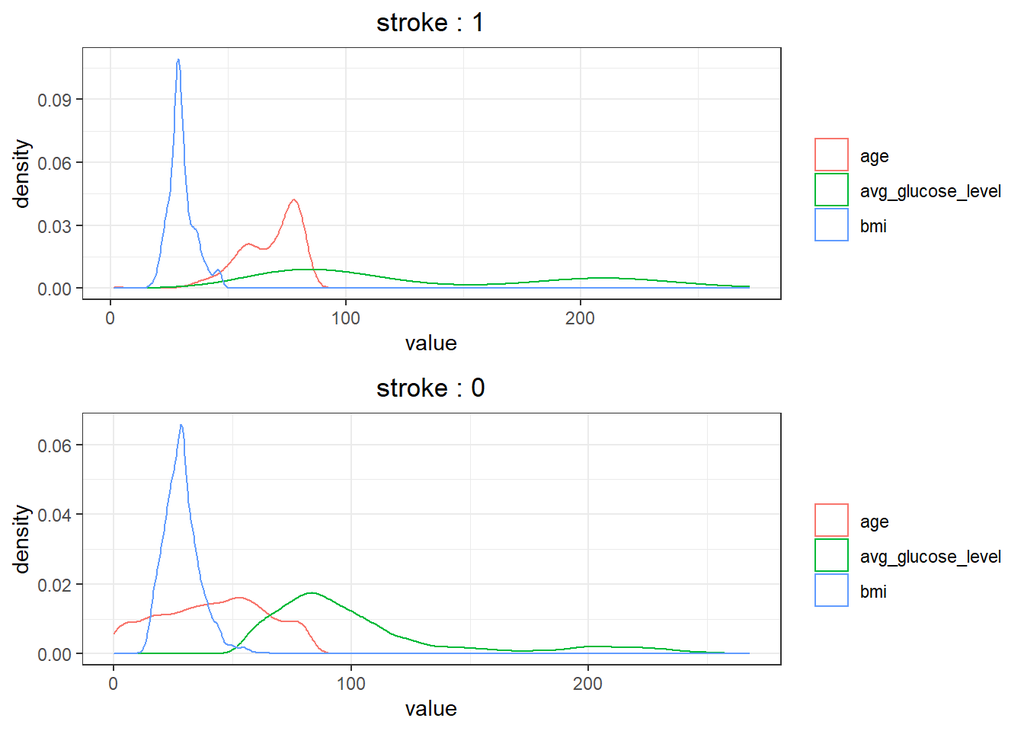

```r
p3 = train_data %>% select(where((is.numeric)),stroke) %>% gather(key='variable', value='value',-stroke) %>% filter(stroke==1) %>% ggplot(aes(x=value,color=variable)) + geom_density() + labs(title="stroke : 1",color='') + theme_bw() + theme(plot.title = element_text(hjust = 0.5))
p4 = train_data %>% select(where((is.numeric)),stroke) %>% gather(key='variable', value='value',-stroke) %>% filter(stroke==0) %>% ggplot(aes(x=value,color=variable)) + geom_density() + labs(title="stroke : 0",color='') + theme_bw() + theme(plot.title = element_text(hjust = 0.5))
grid.arrange(p3,p4,nrow=2)
```

stroke 별로 age 변수에서 분포의 차이가 약간 있다.

## 문제6

타겟 변수와 범주형 변수에 대한 카이스퀘어 독립성 검정을 진행하고 다음과 같이 출력하세요.(데이터프레임을 만든 후, for 문으로 독립성 검정을 진행하여 chi 변수에 검정 결과를 넣으세요.)

```r
cate_var = train_data %>% select(where(is.factor),-stroke) %>% colnames()
result = data.frame(cate_var,chi=rep(NA,7),stringsAsFactors = F)
for(i in 1:7){
  data_table = table(as_vector(train_data[,cate_var[i],with=F]),train_data$stroke)
  a= chisq.test(data_table)
  if(a$p.value < 0.05){
    result$chi[i] = 'denied'
  } else{
    result$chi[i] = 'accept'
  }
}
result
```

```
##         cate_var    chi
## 1         gender accept
## 2   hypertension denied
## 3  heart_disease denied
## 4   ever_married denied
## 5      work_type denied
## 6 Residence_type accept
## 7 smoking_status denied
```

## 문제7

카이스퀘어 독립성 검정에서 가설을 기각하지 못한 범주형 변수를 제거하세요

```r
train_data = train_data %>% select(-c(gender,Residence_type))
```

## 문제8

train data에서 했던 전처리 방법들을 사용하여 전처리 하세요. -‘bmi’ 변수의 자료형을 바꾸고 mean imputation하기

```r
test_data = test_data %>% mutate(bmi=as.numeric(bmi)) %>% mutate(bmi=mean_imputation(bmi))
```

평균인 29.15319로 대체

-문자형 변수 자료형 바꾸기

```r
test_data = test_data %>% mutate_if(is.character,as.factor)
test_data = test_data %>% mutate_if(is.integer,as.factor) # 범주형 변수 생성
```

-‘id’ 및 train 데이터에서 제거된 범주형 변수 제거하기

```r
test_data = test_data %>% select(-c(id,gender,Residence_type))
str(test_data)
```

```
## Classes 'data.table' and 'data.frame':   1023 obs. of  9 variables:
##  $ age              : num  81 50 52 65 59 58 77 82 73 76 ...
##  $ hypertension     : Factor w/ 2 levels "0","1": 1 2 2 1 1 1 2 1 2 1 ...
##  $ heart_disease    : Factor w/ 2 levels "0","1": 1 1 1 1 1 1 1 1 1 1 ...
##  $ ever_married     : Factor w/ 2 levels "No","Yes": 2 2 2 2 2 1 2 2 2 2 ...
##  $ work_type        : Factor w/ 5 levels "children","Govt_job",..: 4 5 5 4 4 4 5 4 5 4 ...
##  $ avg_glucose_level: num  186 167 233 101 212 ...
##  $ bmi              : num  29 30.9 48.9 28.2 29.2 ...
##  $ smoking_status   : Factor w/ 4 levels "formerly smoked",..: 1 2 2 1 1 4 2 2 2 4 ...
##  $ stroke           : Factor w/ 2 levels "0","1": 2 2 2 2 2 2 2 2 2 2 ...
##  - attr(*, ".internal.selfref")=<externalptr>
```

## chapter2.Catboost

```r
library(catboost)
library(caret)
library(MLmetrics)
```

## 문제0

Catboost 모델의 특성 및 대표적인 파라미터에 대해 간단히 설명하세요

```r
# Catboost는 gradient boosting의 한 종류로, ordered boosting, random permutation, Ordered Target Encoding 등의 기법을 통해 오버피팅을 감소시킨다.
# 대표적인 파라미터로는 손실함수, 트리 깊이, 학습률 등이 있다.
```

## 문제1

expand.grid를 사용하여 다음과 같은 데이터 프레임을 만드세요. (데이터 프레임명: logloss_cb)

```r
logloss_cb = expand.grid(depth=c(4,6,8),iterations=c(100,200),logloss=NA)
logloss_cb
```

```
##   depth iterations logloss
## 1     4        100      NA
## 2     6        100      NA
## 3     8        100      NA
## 4     4        200      NA
## 5     6        200      NA
## 6     8        200      NA
```

## 문제2

Catboost에 대해 depth와 iteration 파라미터 튜닝을 위한 grid search 5-fold CV를 진행하세요

```r
set.seed(1234)
index = createFolds(train_data$stroke,k=5,list=F)
cv_start = Sys.time()
for(i in 1:6){
  temp = NULL

  for(k in 1:5){

    cv_train = train_data[which(index==k),]
    cv_test = train_data[which(index==k),]

    #catboost에 맞는 형식으로 전환
    train_pool = catboost.load_pool(data=cv_train[,-"stroke"],label = as.double(cv_train$stroke))
    test_pool = catboost.load_pool(data=cv_test[,-"stroke"],label = as.double(cv_train$stroke))

    #시작시간 및 모수 설정
    start =Sys.time()
    param =list(loss_function='Logloss',random_seed = 1234, iterations = logloss_cb[i,2],depth=logloss_cb[i,1],custom_loss ='Logloss')

    #catboost 학습 및 시간 측정
    cat = catboost.train(learn_pool=train_pool,test_pool = test_pool, params = param)
    test_error <- read.table("catboost_info/test_error.tsv", sep = "\t", header = TRUE)
    temp = c(temp,test_error[nrow(test_error),'Logloss'])

  }
  logloss_cb[i,'logloss'] = min(temp)
}
```

```
## Learning rate set to 0.082078
## 0:   learn: 0.6313310    test: 0.6313310 best: 0.6313310 (0) total: 174ms    remaining: 17.2s
## 1:   learn: 0.5801591    test: 0.5801591 best: 0.5801591 (1) total: 187ms    remaining: 9.18s
## 2:   learn: 0.5358340    test: 0.5358340 best: 0.5358340 (2) total: 206ms    remaining: 6.67s
## 3:   learn: 0.4980171    test: 0.4980171 best: 0.4980171 (3) total: 215ms    remaining: 5.16s
## 4:   learn: 0.4622324    test: 0.4622324 best: 0.4622324 (4) total: 223ms    remaining: 4.24s
## 5:   learn: 0.4327185    test: 0.4327185 best: 0.4327185 (5) total: 231ms    remaining: 3.61s
## 6:   learn: 0.4060265    test: 0.4060265 best: 0.4060265 (6) total: 247ms    remaining: 3.28s
## 7:   learn: 0.3822821    test: 0.3822821 best: 0.3822821 (7) total: 260ms    remaining: 2.99s
## 8:   learn: 0.3605631    test: 0.3605631 best: 0.3605631 (8) total: 265ms    remaining: 2.68s
## 9:   learn: 0.3426408    test: 0.3426408 best: 0.3426408 (9) total: 269ms    remaining: 2.42s
## 10:  learn: 0.3262330    test: 0.3262330 best: 0.3262330 (10)    total: 274ms    remaining: 2.21s
## 11:  learn: 0.3099778    test: 0.3099778 best: 0.3099778 (11)    total: 276ms    remaining: 2.02s
## 12:  learn: 0.2966021    test: 0.2966021 best: 0.2966021 (12)    total: 279ms    remaining: 1.87s
## 13:  learn: 0.2841528    test: 0.2841528 best: 0.2841528 (13)    total: 283ms    remaining: 1.74s
```

[output cut: 4634 more lines]

```r
Sys.time()-cv_start
```

```
## Time difference of 1.755983 mins
```

```r
logloss_cb
```

```
##   depth iterations    logloss
## 1     4        100 0.12939167
## 2     6        100 0.12436487
## 3     8        100 0.11689935
## 4     4        200 0.08406320
## 5     6        200 0.06154489
## 6     8        200 0.05006100
```

결과

## 문제3

logloss_cb에서 가장 낮은 logloss 값의 행을 출력하세요.

```r
logloss_cb %>% arrange(logloss) %>% head(1)
```

```
##   depth iterations  logloss
## 1     8        200 0.050061
```

depth =8, iterations =200일때, logloss=0.050061로 최소!

## 문제4

가장 낮은 logloss 값의 파라미터로 전체 데이터를 학습시켜 test set에 대한 logloss값을 구하세요.

```r
#catboost에 맞는 형식으로 전환
train_pool_t = catboost.load_pool(data=train_data[,-"stroke"],label = as.double(train_data$stroke))
test_pool_t = catboost.load_pool(data=test_data[,-"stroke"],label = as.double(test_data$stroke))

#depth =8, iteration =200으로 모수 설정
param =list(loss_function='Logloss',random_seed = 1234, iterations = 200,depth=8,custom_loss ='Logloss')

cat_total = catboost.train(learn_pool=train_pool_t,test_pool = test_pool_t, params = param)
```

```
## Learning rate set to 0.09036
## 0:   learn: 0.5556438    test: 0.5576122 best: 0.5576122 (0) total: 65.5ms   remaining: 13s
## 1:   learn: 0.4611782    test: 0.4643910 best: 0.4643910 (1) total: 134ms    remaining: 13.3s
## 2:   learn: 0.3814965    test: 0.3852656 best: 0.3852656 (2) total: 212ms    remaining: 14s
## 3:   learn: 0.3172835    test: 0.3209734 best: 0.3209734 (3) total: 282ms    remaining: 13.8s
## 4:   learn: 0.2765303    test: 0.2799525 best: 0.2799525 (4) total: 317ms    remaining: 12.4s
## 5:   learn: 0.2483902    test: 0.2519264 best: 0.2519264 (5) total: 387ms    remaining: 12.5s
## 6:   learn: 0.2319652    test: 0.2355955 best: 0.2355955 (6) total: 398ms    remaining: 11s
## 7:   learn: 0.2139000    test: 0.2174686 best: 0.2174686 (7) total: 427ms    remaining: 10.2s
## 8:   learn: 0.2029459    test: 0.2068530 best: 0.2068530 (8) total: 446ms    remaining: 9.47s
## 9:   learn: 0.1931825    test: 0.1970437 best: 0.1970437 (9) total: 460ms    remaining: 8.74s
## 10:  learn: 0.1852209    test: 0.1903629 best: 0.1903629 (10)    total: 498ms    remaining: 8.56s
## 11:  learn: 0.1808904    test: 0.1860978 best: 0.1860978 (11)    total: 505ms    remaining: 7.92s
## 12:  learn: 0.1773549    test: 0.1826333 best: 0.1826333 (12)    total: 522ms    remaining: 7.5s
## 13:  learn: 0.1718376    test: 0.1782569 best: 0.1782569 (13)    total: 563ms    remaining: 7.48s
```

[output cut: 191 more lines]

```r
test_error = read.table("catboost_info/test_error.tsv", sep = "\t", header = TRUE)
test_error[nrow(test_error),'Logloss']
```

```
## [1] 0.1893823
```

0.1893823

## chapter3

```r
library(factoextra)
library(cluster)
```

필요한 라이브러리 불러오기

## 문제1

수치형 변수(age, avg_glucose_level, bmi)에 대해 scale 함수로 정규화 스케일링을 하세요.

```r
#문제1
scale_train_data = train_data %>% select(where(is.numeric)) %>% scale()
```

## 문제2

fviz_nbclust 함수로 다음과 같이 시각화 한 뒤, 적절한 K값이 무엇인지 설명하세요.

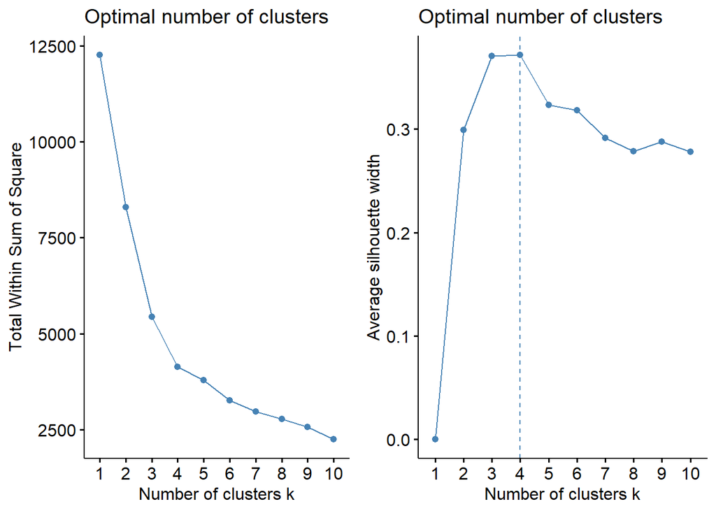

```r
p5 = fviz_nbclust(scale_train_data,kmeans,method='wss')
p6 = fviz_nbclust(scale_train_data,kmeans,method='silhouette')
grid.arrange(p5,p6,ncol=2)
```

적절한 k 값은 오른쪽 그래프에서 점선으로 나타난 4

## 문제3

K-means 클러스터링을 한 후, 다음과 같이 시각화하세요. (nstart = 1, iter.max=30, seed: 1234)

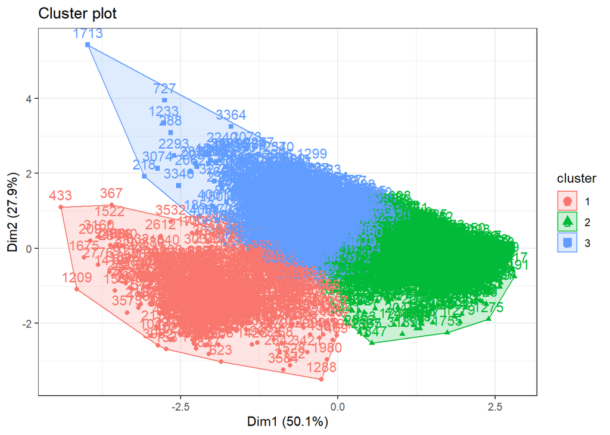

```r
set.seed(1234)
km = kmeans(scale_train_data,centers = 3, nstart = 1, iter.max =30)
fviz_cluster(km,data=scale_train_data) + theme_bw()
```

## 문제4

사용한 변수인 age, avg_glucose_level(평균 혈당), bmi(bmi 수치)에 대해 다음과 같이 box_plot 시각화를 하고, 클러스터 별로 해석해보세요. (사용 색 : #845ec2, #ffc75f, #ff5e78)

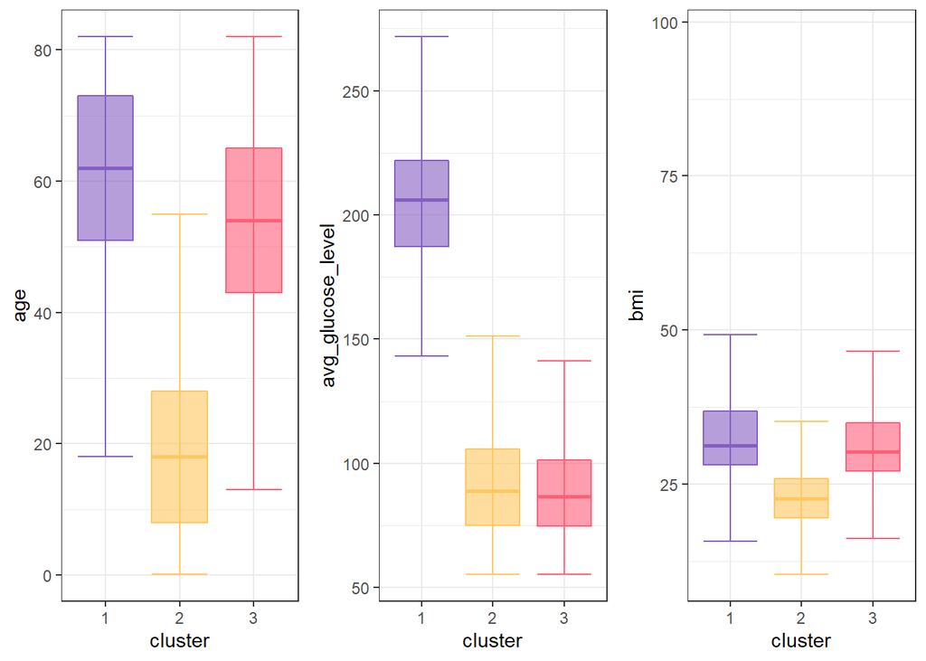

```r
pp = train_data %>% select(where(is.numeric)) %>% mutate(cluster= km$cluster)
p7 = pp %>% ggplot(aes(x=factor(cluster),y=age)) + geom_boxplot(outlier.shape = NA, alpha=0.6,fill=c( '#845ec2', '#ffc75f', '#ff5e78'),color=c( '#845ec2', '#ffc75f', '#ff5e78')) + stat_boxplot(geom='errorbar',color=c( '#845ec2', '#ffc75f', '#ff5e78')) + labs(x='cluster') + theme_bw()
p8 = pp %>% ggplot(aes(x=factor(cluster),y=avg_glucose_level)) + geom_boxplot(outlier.shape = NA, alpha=0.6,fill=c( '#845ec2', '#ffc75f', '#ff5e78'),color=c( '#845ec2', '#ffc75f', '#ff5e78')) + stat_boxplot(geom='errorbar',color=c( '#845ec2', '#ffc75f', '#ff5e78')) + labs(x='cluster') + theme_bw()
p9 = pp %>% ggplot(aes(x=factor(cluster),y=bmi)) + geom_boxplot(outlier.shape = NA, alpha=0.6,fill=c( '#845ec2', '#ffc75f', '#ff5e78'),color=c( '#845ec2', '#ffc75f', '#ff5e78')) + stat_boxplot(geom='errorbar',color=c( '#845ec2', '#ffc75f', '#ff5e78')) + labs(x='cluster') + theme_bw()
grid.arrange(p7,p8,p9,ncol=3)
```